# Risk Factor Analysis

## Outcome Variable

**Outcome Variable:** ever_stunted

## Predictor Variables

**Intervention Variable:** feducyrs

**Adjustment Set:**

- arm
- W_mage
- meducyrs
- hhwealth_quart
- W_mhtcm
- W_mwtkg
- W_mbmi
- W_gagebrth
- W_birthwt
- W_birthlen
- single
- delta_W_mage
- delta_meducyrs
- delta_hhwealth_quart
- delta_W_mhtcm
- delta_W_mwtkg
- delta_W_mbmi
- delta_W_gagebrth
- delta_W_birthwt
- delta_W_birthlen
- delta_single

## Stratifying Variables

The analysis was stratified on these variable(s):

- agecat
- studyid
- country

## Data Summary

| agecat | studyid | country | feducyrs | ever_stunted | n_cell | n |
| --- | --- | --- | --- | --- | --- | --- |
| 0-24 months | COHORTS | GUATEMALA | High | 0 | 55 | 1250 |
| 0-24 months | COHORTS | GUATEMALA | High | 1 | 179 | 1250 |
| 0-24 months | COHORTS | GUATEMALA | Low | 0 | 122 | 1250 |
| 0-24 months | COHORTS | GUATEMALA | Low | 1 | 445 | 1250 |
| 0-24 months | COHORTS | GUATEMALA | Medium | 0 | 114 | 1250 |
| 0-24 months | COHORTS | GUATEMALA | Medium | 1 | 335 | 1250 |
| 0-24 months | COHORTS | INDIA | High | 0 | 404 | 1447 |
| 0-24 months | COHORTS | INDIA | High | 1 | 163 | 1447 |
| 0-24 months | COHORTS | INDIA | Low | 0 | 240 | 1447 |
| 0-24 months | COHORTS | INDIA | Low | 1 | 232 | 1447 |
| 0-24 months | COHORTS | INDIA | Medium | 0 | 256 | 1447 |
| 0-24 months | COHORTS | INDIA | Medium | 1 | 152 | 1447 |
| 0-24 months | COHORTS | PHILIPPINES | High | 0 | 466 | 2880 |
| 0-24 months | COHORTS | PHILIPPINES | High | 1 | 565 | 2880 |
| 0-24 months | COHORTS | PHILIPPINES | Low | 0 | 160 | 2880 |
| 0-24 months | COHORTS | PHILIPPINES | Low | 1 | 668 | 2880 |
| 0-24 months | COHORTS | PHILIPPINES | Medium | 0 | 267 | 2880 |
| 0-24 months | COHORTS | PHILIPPINES | Medium | 1 | 754 | 2880 |
| 0-24 months | GMS-Nepal | NEPAL | High | 0 | 79 | 696 |
| 0-24 months | GMS-Nepal | NEPAL | High | 1 | 94 | 696 |
| 0-24 months | GMS-Nepal | NEPAL | Low | 0 | 92 | 696 |
| 0-24 months | GMS-Nepal | NEPAL | Low | 1 | 204 | 696 |
| 0-24 months | GMS-Nepal | NEPAL | Medium | 0 | 79 | 696 |
| 0-24 months | GMS-Nepal | NEPAL | Medium | 1 | 148 | 696 |
| 0-24 months | JiVitA-3 | BANGLADESH | High | 0 | 3975 | 26233 |
| 0-24 months | JiVitA-3 | BANGLADESH | High | 1 | 2529 | 26233 |
| 0-24 months | JiVitA-3 | BANGLADESH | Low | 0 | 4982 | 26233 |
| 0-24 months | JiVitA-3 | BANGLADESH | Low | 1 | 5803 | 26233 |
| 0-24 months | JiVitA-3 | BANGLADESH | Medium | 0 | 4339 | 26233 |
| 0-24 months | JiVitA-3 | BANGLADESH | Medium | 1 | 4605 | 26233 |

[output cut: 330 more lines]

The following strata were considered:

- agecat: 0-24 months, studyid: COHORTS, country: GUATEMALA
- agecat: 0-24 months, studyid: COHORTS, country: INDIA
- agecat: 0-24 months, studyid: COHORTS, country: PHILIPPINES
- agecat: 0-24 months, studyid: GMS-Nepal, country: NEPAL
- agecat: 0-24 months, studyid: JiVitA-3, country: BANGLADESH
- agecat: 0-24 months, studyid: JiVitA-4, country: BANGLADESH
- agecat: 0-24 months, studyid: LCNI-5, country: MALAWI
- agecat: 0-24 months, studyid: MAL-ED, country: BANGLADESH
- agecat: 0-24 months, studyid: MAL-ED, country: INDIA
- agecat: 0-24 months, studyid: MAL-ED, country: NEPAL
- agecat: 0-24 months, studyid: MAL-ED, country: PERU
- agecat: 0-24 months, studyid: MAL-ED, country: SOUTH AFRICA
- agecat: 0-24 months, studyid: MAL-ED, country: TANZANIA, UNITED REPUBLIC OF
- agecat: 0-24 months, studyid: NIH-Crypto, country: BANGLADESH
- agecat: 0-24 months, studyid: PROBIT, country: BELARUS
- agecat: 0-24 months, studyid: PROVIDE, country: BANGLADESH
- agecat: 0-24 months, studyid: SAS-CompFeed, country: INDIA
- agecat: 0-24 months, studyid: SAS-FoodSuppl, country: INDIA
- agecat: 0-24 months, studyid: TanzaniaChild2, country: TANZANIA, UNITED REPUBLIC OF
- agecat: 0-24 months, studyid: ZVITAMBO, country: ZIMBABWE
- agecat: 0-6 months, studyid: COHORTS, country: GUATEMALA
- agecat: 0-6 months, studyid: COHORTS, country: INDIA
- agecat: 0-6 months, studyid: COHORTS, country: PHILIPPINES
- agecat: 0-6 months, studyid: GMS-Nepal, country: NEPAL
- agecat: 0-6 months, studyid: JiVitA-3, country: BANGLADESH
- agecat: 0-6 months, studyid: JiVitA-4, country: BANGLADESH
- agecat: 0-6 months, studyid: LCNI-5, country: MALAWI
- agecat: 0-6 months, studyid: MAL-ED, country: BANGLADESH
- agecat: 0-6 months, studyid: MAL-ED, country: INDIA
- agecat: 0-6 months, studyid: MAL-ED, country: NEPAL
- agecat: 0-6 months, studyid: MAL-ED, country: PERU
- agecat: 0-6 months, studyid: MAL-ED, country: SOUTH AFRICA
- agecat: 0-6 months, studyid: MAL-ED, country: TANZANIA, UNITED REPUBLIC OF
- agecat: 0-6 months, studyid: NIH-Crypto, country: BANGLADESH
- agecat: 0-6 months, studyid: PROBIT, country: BELARUS
- agecat: 0-6 months, studyid: PROVIDE, country: BANGLADESH
- agecat: 0-6 months, studyid: SAS-CompFeed, country: INDIA
- agecat: 0-6 months, studyid: SAS-FoodSuppl, country: INDIA
- agecat: 0-6 months, studyid: TanzaniaChild2, country: TANZANIA, UNITED REPUBLIC OF
- agecat: 0-6 months, studyid: ZVITAMBO, country: ZIMBABWE
- agecat: 6-24 months, studyid: COHORTS, country: GUATEMALA
- agecat: 6-24 months, studyid: COHORTS, country: INDIA
- agecat: 6-24 months, studyid: COHORTS, country: PHILIPPINES
- agecat: 6-24 months, studyid: GMS-Nepal, country: NEPAL
- agecat: 6-24 months, studyid: JiVitA-3, country: BANGLADESH
- agecat: 6-24 months, studyid: JiVitA-4, country: BANGLADESH
- agecat: 6-24 months, studyid: LCNI-5, country: MALAWI
- agecat: 6-24 months, studyid: MAL-ED, country: BANGLADESH
- agecat: 6-24 months, studyid: MAL-ED, country: INDIA
- agecat: 6-24 months, studyid: MAL-ED, country: NEPAL
- agecat: 6-24 months, studyid: MAL-ED, country: PERU
- agecat: 6-24 months, studyid: MAL-ED, country: SOUTH AFRICA
- agecat: 6-24 months, studyid: MAL-ED, country: TANZANIA, UNITED REPUBLIC OF
- agecat: 6-24 months, studyid: NIH-Crypto, country: BANGLADESH
- agecat: 6-24 months, studyid: PROBIT, country: BELARUS
- agecat: 6-24 months, studyid: PROVIDE, country: BANGLADESH
- agecat: 6-24 months, studyid: SAS-CompFeed, country: INDIA
- agecat: 6-24 months, studyid: SAS-FoodSuppl, country: INDIA
- agecat: 6-24 months, studyid: TanzaniaChild2, country: TANZANIA, UNITED REPUBLIC OF
- agecat: 6-24 months, studyid: ZVITAMBO, country: ZIMBABWE

### Dropped Strata

Some strata were dropped due to rare outcomes:

- agecat: 0-24 months, studyid: MAL-ED, country: TANZANIA, UNITED REPUBLIC OF
- agecat: 0-6 months, studyid: MAL-ED, country: NEPAL
- agecat: 6-24 months, studyid: MAL-ED, country: NEPAL
- agecat: 6-24 months, studyid: MAL-ED, country: TANZANIA, UNITED REPUBLIC OF

## Methods Detail

We’re interested in the causal parameters $E[Y_a]$ for all values of $a \in \mathcal{A}$. These parameters represent the mean outcome if, possibly contrary to fact, we intervened to set all units to have $A=a$. Under the randomization and positivity assumptions, these are identified by the statistical parameters $\psi_a=E_W[E_{Y|A,W}(Y|A=a,W)]$. In addition, we’re interested in the mean of $Y$, $E[Y]$ under no intervention (the observed mean). We will estimate these parameters by using SuperLearner to fit the relevant likelihood factors – $E_{Y|A,W}(Y|A=a,W)$ and $p(A=a|W)$, and then updating our likelihood fit using a joint TMLE.

For unadjusted analyses ($W=\{\}$), initial likelihoods were estimated using Lrnr_glm to estimate the simple $E(Y|A)$ and Lrnr_mean to estimate $p(A)$. For adjusted analyses, a small library containing Lrnr_glmnet, Lrnr_xgboost, and Lrnr_mean was used.

Having estimated these parameters, we will then use the delta method to estimate relative risks and attributable risks relative to a prespecified baseline level of $A$.

# Results Detail

## Results Plots

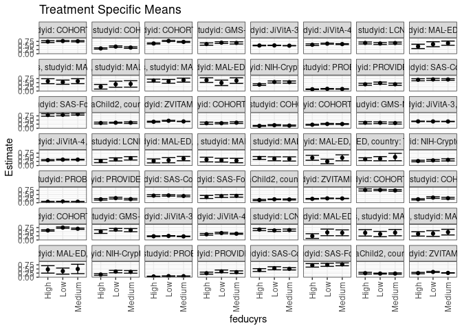

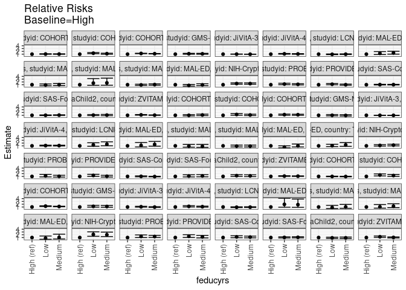

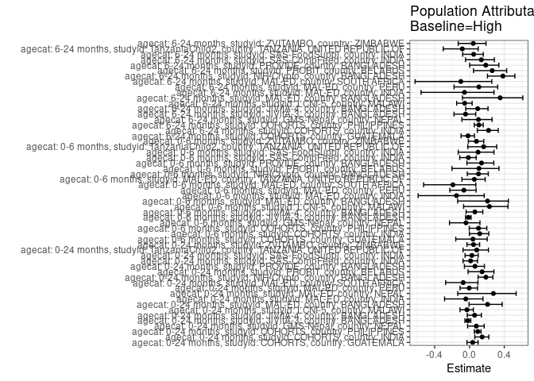

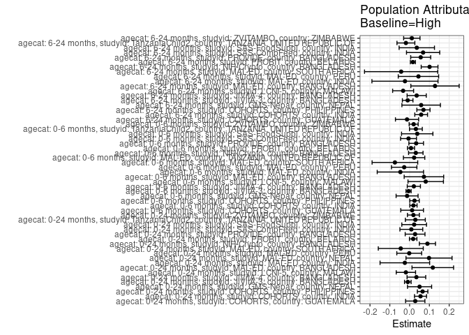

## Results Table

### Parameter: TSM

| agecat | studyid | country | intervention_level | baseline_level | estimate | ci_lower | ci_upper |
| --- | --- | --- | --- | --- | --- | --- | --- |
| 0-24 months | COHORTS | GUATEMALA | High | NA | 0.7386393 | 0.6840705 | 0.7932081 |
| 0-24 months | COHORTS | GUATEMALA | Low | NA | 0.7735407 | 0.7392523 | 0.8078290 |
| 0-24 months | COHORTS | GUATEMALA | Medium | NA | 0.7604391 | 0.7216560 | 0.7992222 |
| 0-24 months | COHORTS | INDIA | High | NA | 0.3229201 | 0.2848295 | 0.3610107 |
| 0-24 months | COHORTS | INDIA | Low | NA | 0.4343811 | 0.3911925 | 0.4775697 |
| 0-24 months | COHORTS | INDIA | Medium | NA | 0.3765251 | 0.3314255 | 0.4216246 |
| 0-24 months | COHORTS | PHILIPPINES | High | NA | 0.6242640 | 0.5922058 | 0.6563221 |
| 0-24 months | COHORTS | PHILIPPINES | Low | NA | 0.7779112 | 0.7449471 | 0.8108752 |
| 0-24 months | COHORTS | PHILIPPINES | Medium | NA | 0.7207067 | 0.6906319 | 0.7507815 |
| 0-24 months | GMS-Nepal | NEPAL | High | NA | 0.5904406 | 0.5201582 | 0.6607230 |
| 0-24 months | GMS-Nepal | NEPAL | Low | NA | 0.6741284 | 0.6217130 | 0.7265438 |
| 0-24 months | GMS-Nepal | NEPAL | Medium | NA | 0.6583396 | 0.5921931 | 0.7244862 |
| 0-24 months | JiVitA-3 | BANGLADESH | High | NA | 0.5021092 | 0.4839573 | 0.5202611 |
| 0-24 months | JiVitA-3 | BANGLADESH | Low | NA | 0.5085768 | 0.4955858 | 0.5215679 |
| 0-24 months | JiVitA-3 | BANGLADESH | Medium | NA | 0.4909789 | 0.4794632 | 0.5024945 |
| 0-24 months | JiVitA-4 | BANGLADESH | High | NA | 0.5477207 | 0.4967399 | 0.5987015 |
| 0-24 months | JiVitA-4 | BANGLADESH | Low | NA | 0.6132725 | 0.5826188 | 0.6439263 |
| 0-24 months | JiVitA-4 | BANGLADESH | Medium | NA | 0.5862272 | 0.5604945 | 0.6119600 |
| 0-24 months | LCNI-5 | MALAWI | High | NA | 0.6558670 | 0.5972232 | 0.7145108 |
| 0-24 months | LCNI-5 | MALAWI | Low | NA | 0.6223374 | 0.5671275 | 0.6775472 |
| 0-24 months | LCNI-5 | MALAWI | Medium | NA | 0.6498599 | 0.5925679 | 0.7071519 |
| 0-24 months | MAL-ED | BANGLADESH | High | NA | 0.4465826 | 0.3143010 | 0.5788641 |
| 0-24 months | MAL-ED | BANGLADESH | Low | NA | 0.5794943 | 0.4298213 | 0.7291674 |
| 0-24 months | MAL-ED | BANGLADESH | Medium | NA | 0.6429180 | 0.5153601 | 0.7704759 |
| 0-24 months | MAL-ED | INDIA | High | NA | 0.5954239 | 0.4455188 | 0.7453290 |
| 0-24 months | MAL-ED | INDIA | Low | NA | 0.5371295 | 0.4102411 | 0.6640179 |
| 0-24 months | MAL-ED | INDIA | Medium | NA | 0.5969733 | 0.4472090 | 0.7467376 |
| 0-24 months | MAL-ED | NEPAL | High | NA | 0.2590742 | 0.1184511 | 0.3996973 |
| 0-24 months | MAL-ED | NEPAL | Low | NA | 0.4101823 | 0.2246292 | 0.5957354 |
| 0-24 months | MAL-ED | NEPAL | Medium | NA | 0.4290616 | 0.2339761 | 0.6241472 |

[output cut: 138 more lines]

### Parameter: E(Y)

| agecat | studyid | country | intervention_level | baseline_level | estimate | ci_lower | ci_upper |
| --- | --- | --- | --- | --- | --- | --- | --- |
| 0-24 months | COHORTS | GUATEMALA | NA | NA | 0.7672000 | 0.7437624 | 0.7906376 |
| 0-24 months | COHORTS | INDIA | NA | NA | 0.3780235 | 0.3530310 | 0.4030160 |
| 0-24 months | COHORTS | PHILIPPINES | NA | NA | 0.6899306 | 0.6730355 | 0.7068256 |
| 0-24 months | GMS-Nepal | NEPAL | NA | NA | 0.6408046 | 0.6051362 | 0.6764730 |
| 0-24 months | JiVitA-3 | BANGLADESH | NA | NA | 0.4931575 | 0.4852626 | 0.5010523 |
| 0-24 months | JiVitA-4 | BANGLADESH | NA | NA | 0.5820697 | 0.5655159 | 0.5986236 |
| 0-24 months | LCNI-5 | MALAWI | NA | NA | 0.6371464 | 0.6040748 | 0.6702180 |
| 0-24 months | MAL-ED | BANGLADESH | NA | NA | 0.5637584 | 0.4838620 | 0.6436548 |
| 0-24 months | MAL-ED | INDIA | NA | NA | 0.5714286 | 0.4911565 | 0.6517006 |
| 0-24 months | MAL-ED | NEPAL | NA | NA | 0.3571429 | 0.2617885 | 0.4524972 |
| 0-24 months | MAL-ED | PERU | NA | NA | 0.6280000 | 0.5679657 | 0.6880343 |
| 0-24 months | MAL-ED | SOUTH AFRICA | NA | NA | 0.6181818 | 0.5269763 | 0.7093874 |
| 0-24 months | NIH-Crypto | BANGLADESH | NA | NA | 0.4775726 | 0.4419904 | 0.5131548 |
| 0-24 months | PROBIT | BELARUS | NA | NA | 0.1247395 | 0.1090645 | 0.1404144 |
| 0-24 months | PROVIDE | BANGLADESH | NA | NA | 0.4357143 | 0.3989556 | 0.4724730 |
| 0-24 months | SAS-CompFeed | INDIA | NA | NA | 0.6908497 | 0.6505448 | 0.7311545 |
| 0-24 months | SAS-FoodSuppl | INDIA | NA | NA | 0.8277512 | 0.7915095 | 0.8639929 |
| 0-24 months | TanzaniaChild2 | TANZANIA, UNITED REPUBLIC OF | NA | NA | 0.3466219 | 0.3275107 | 0.3657331 |
| 0-24 months | ZVITAMBO | ZIMBABWE | NA | NA | 0.4136118 | 0.4053631 | 0.4218605 |
| 0-6 months | COHORTS | GUATEMALA | NA | NA | 0.3196078 | 0.2909760 | 0.3482397 |
| 0-6 months | COHORTS | INDIA | NA | NA | 0.1639690 | 0.1447117 | 0.1832264 |
| 0-6 months | COHORTS | PHILIPPINES | NA | NA | 0.2381944 | 0.2226342 | 0.2537546 |
| 0-6 months | GMS-Nepal | NEPAL | NA | NA | 0.3189655 | 0.2843148 | 0.3536162 |
| 0-6 months | JiVitA-3 | BANGLADESH | NA | NA | 0.4111421 | 0.4035964 | 0.4186878 |
| 0-6 months | JiVitA-4 | BANGLADESH | NA | NA | 0.3469880 | 0.3313196 | 0.3626563 |
| 0-6 months | LCNI-5 | MALAWI | NA | NA | 0.3558052 | 0.2982716 | 0.4133389 |
| 0-6 months | MAL-ED | BANGLADESH | NA | NA | 0.3489933 | 0.2722008 | 0.4257857 |
| 0-6 months | MAL-ED | INDIA | NA | NA | 0.3129252 | 0.2377120 | 0.3881383 |
| 0-6 months | MAL-ED | PERU | NA | NA | 0.4280000 | 0.3665434 | 0.4894566 |
| 0-6 months | MAL-ED | SOUTH AFRICA | NA | NA | 0.3909091 | 0.2993052 | 0.4825130 |
| 0-6 months | MAL-ED | TANZANIA, UNITED REPUBLIC OF | NA | NA | 0.4056604 | 0.3394074 | 0.4719134 |
| 0-6 months | NIH-Crypto | BANGLADESH | NA | NA | 0.3021108 | 0.2694011 | 0.3348205 |
| 0-6 months | PROBIT | BELARUS | NA | NA | 0.0660985 | 0.0554258 | 0.0767711 |
| 0-6 months | PROVIDE | BANGLADESH | NA | NA | 0.2400000 | 0.2083392 | 0.2716608 |
| 0-6 months | SAS-CompFeed | INDIA | NA | NA | 0.4250164 | 0.3969651 | 0.4530677 |
| 0-6 months | SAS-FoodSuppl | INDIA | NA | NA | 0.3894231 | 0.3425088 | 0.4363374 |
| 0-6 months | TanzaniaChild2 | TANZANIA, UNITED REPUBLIC OF | NA | NA | 0.1951322 | 0.1792173 | 0.2110471 |
| 0-6 months | ZVITAMBO | ZIMBABWE | NA | NA | 0.2565977 | 0.2492783 | 0.2639171 |
| 6-24 months | COHORTS | GUATEMALA | NA | NA | 0.7617329 | 0.7327499 | 0.7907158 |
| 6-24 months | COHORTS | INDIA | NA | NA | 0.2663274 | 0.2410848 | 0.2915700 |
| 6-24 months | COHORTS | PHILIPPINES | NA | NA | 0.6482312 | 0.6273346 | 0.6691278 |
| 6-24 months | GMS-Nepal | NEPAL | NA | NA | 0.5656566 | 0.5167753 | 0.6145378 |
| 6-24 months | JiVitA-3 | BANGLADESH | NA | NA | 0.2152036 | 0.2057612 | 0.2246461 |
| 6-24 months | JiVitA-4 | BANGLADESH | NA | NA | 0.3789503 | 0.3597979 | 0.3981028 |
| 6-24 months | LCNI-5 | MALAWI | NA | NA | 0.5983027 | 0.5621404 | 0.6344650 |
| 6-24 months | MAL-ED | BANGLADESH | NA | NA | 0.3636364 | 0.2625541 | 0.4647186 |
| 6-24 months | MAL-ED | INDIA | NA | NA | 0.4086022 | 0.3081534 | 0.5090509 |
| 6-24 months | MAL-ED | PERU | NA | NA | 0.4132231 | 0.3251210 | 0.5013252 |
| 6-24 months | MAL-ED | SOUTH AFRICA | NA | NA | 0.4310345 | 0.3024734 | 0.5595956 |
| 6-24 months | NIH-Crypto | BANGLADESH | NA | NA | 0.2628458 | 0.2244546 | 0.3012371 |
| 6-24 months | PROBIT | BELARUS | NA | NA | 0.0639065 | 0.0521855 | 0.0756275 |
| 6-24 months | PROVIDE | BANGLADESH | NA | NA | 0.3004386 | 0.2583143 | 0.3425629 |
| 6-24 months | SAS-CompFeed | INDIA | NA | NA | 0.5024631 | 0.4586872 | 0.5462389 |
| 6-24 months | SAS-FoodSuppl | INDIA | NA | NA | 0.7572016 | 0.7031798 | 0.8112234 |
| 6-24 months | TanzaniaChild2 | TANZANIA, UNITED REPUBLIC OF | NA | NA | 0.2263323 | 0.2057897 | 0.2468748 |
| 6-24 months | ZVITAMBO | ZIMBABWE | NA | NA | 0.2601449 | 0.2506947 | 0.2695951 |

### Parameter: RR

| agecat | studyid | country | intervention_level | baseline_level | estimate | ci_lower | ci_upper |
| --- | --- | --- | --- | --- | --- | --- | --- |
| 0-24 months | COHORTS | GUATEMALA | High | High | 1.0000000 | 1.0000000 | 1.000000 |
| 0-24 months | COHORTS | GUATEMALA | Low | High | 1.0472509 | 0.9621595 | 1.139868 |
| 0-24 months | COHORTS | GUATEMALA | Medium | High | 1.0295134 | 0.9428466 | 1.124147 |
| 0-24 months | COHORTS | INDIA | High | High | 1.0000000 | 1.0000000 | 1.000000 |
| 0-24 months | COHORTS | INDIA | Low | High | 1.3451660 | 1.1609444 | 1.558620 |
| 0-24 months | COHORTS | INDIA | Medium | High | 1.1660007 | 0.9949308 | 1.366485 |
| 0-24 months | COHORTS | PHILIPPINES | High | High | 1.0000000 | 1.0000000 | 1.000000 |
| 0-24 months | COHORTS | PHILIPPINES | Low | High | 1.2461254 | 1.1667748 | 1.330872 |
| 0-24 months | COHORTS | PHILIPPINES | Medium | High | 1.1544903 | 1.0820944 | 1.231730 |
| 0-24 months | GMS-Nepal | NEPAL | High | High | 1.0000000 | 1.0000000 | 1.000000 |
| 0-24 months | GMS-Nepal | NEPAL | Low | High | 1.1417379 | 0.9948593 | 1.310301 |
| 0-24 months | GMS-Nepal | NEPAL | Medium | High | 1.1149973 | 0.9582590 | 1.297373 |
| 0-24 months | JiVitA-3 | BANGLADESH | High | High | 1.0000000 | 1.0000000 | 1.000000 |
| 0-24 months | JiVitA-3 | BANGLADESH | Low | High | 1.0128809 | 0.9723770 | 1.055072 |
| 0-24 months | JiVitA-3 | BANGLADESH | Medium | High | 0.9778329 | 0.9404804 | 1.016669 |
| 0-24 months | JiVitA-4 | BANGLADESH | High | High | 1.0000000 | 1.0000000 | 1.000000 |
| 0-24 months | JiVitA-4 | BANGLADESH | Low | High | 1.1196811 | 1.0106966 | 1.240417 |
| 0-24 months | JiVitA-4 | BANGLADESH | Medium | High | 1.0703032 | 0.9682916 | 1.183062 |
| 0-24 months | LCNI-5 | MALAWI | High | High | 1.0000000 | 1.0000000 | 1.000000 |
| 0-24 months | LCNI-5 | MALAWI | Low | High | 0.9488774 | 0.8376315 | 1.074898 |
| 0-24 months | LCNI-5 | MALAWI | Medium | High | 0.9908410 | 0.8753421 | 1.121580 |
| 0-24 months | MAL-ED | BANGLADESH | High | High | 1.0000000 | 1.0000000 | 1.000000 |
| 0-24 months | MAL-ED | BANGLADESH | Low | High | 1.2976197 | 0.8817809 | 1.909564 |
| 0-24 months | MAL-ED | BANGLADESH | Medium | High | 1.4396398 | 1.0109238 | 2.050167 |
| 0-24 months | MAL-ED | INDIA | High | High | 1.0000000 | 1.0000000 | 1.000000 |
| 0-24 months | MAL-ED | INDIA | Low | High | 0.9020959 | 0.6402145 | 1.271101 |
| 0-24 months | MAL-ED | INDIA | Medium | High | 1.0026022 | 0.7038820 | 1.428096 |
| 0-24 months | MAL-ED | NEPAL | High | High | 1.0000000 | 1.0000000 | 1.000000 |
| 0-24 months | MAL-ED | NEPAL | Low | High | 1.5832619 | 0.7839075 | 3.197722 |
| 0-24 months | MAL-ED | NEPAL | Medium | High | 1.6561342 | 0.8165115 | 3.359145 |

[output cut: 138 more lines]

### Parameter: PAR

| agecat | studyid | country | intervention_level | baseline_level | estimate | ci_lower | ci_upper |
| --- | --- | --- | --- | --- | --- | --- | --- |
| 0-24 months | COHORTS | GUATEMALA | High | NA | 0.0285607 | -0.0201835 | 0.0773049 |
| 0-24 months | COHORTS | INDIA | High | NA | 0.0551034 | 0.0246759 | 0.0855309 |
| 0-24 months | COHORTS | PHILIPPINES | High | NA | 0.0656666 | 0.0391703 | 0.0921629 |
| 0-24 months | GMS-Nepal | NEPAL | High | NA | 0.0503640 | -0.0105519 | 0.1112799 |
| 0-24 months | JiVitA-3 | BANGLADESH | High | NA | -0.0089517 | -0.0255543 | 0.0076509 |
| 0-24 months | JiVitA-4 | BANGLADESH | High | NA | 0.0343490 | -0.0127777 | 0.0814758 |
| 0-24 months | LCNI-5 | MALAWI | High | NA | -0.0187206 | -0.0675861 | 0.0301448 |
| 0-24 months | MAL-ED | BANGLADESH | High | NA | 0.1171758 | 0.0121271 | 0.2222246 |
| 0-24 months | MAL-ED | INDIA | High | NA | -0.0239953 | -0.1492331 | 0.1012425 |
| 0-24 months | MAL-ED | NEPAL | High | NA | 0.0980687 | -0.0182816 | 0.2144189 |
| 0-24 months | MAL-ED | PERU | High | NA | -0.0019184 | -0.0646695 | 0.0608328 |
| 0-24 months | MAL-ED | SOUTH AFRICA | High | NA | -0.0445591 | -0.1581522 | 0.0690340 |
| 0-24 months | NIH-Crypto | BANGLADESH | High | NA | 0.0899941 | 0.0492524 | 0.1307358 |
| 0-24 months | PROBIT | BELARUS | High | NA | 0.0180764 | -0.0008065 | 0.0369594 |
| 0-24 months | PROVIDE | BANGLADESH | High | NA | 0.0277137 | -0.0222539 | 0.0776812 |
| 0-24 months | SAS-CompFeed | INDIA | High | NA | 0.0087935 | -0.0488661 | 0.0664531 |
| 0-24 months | SAS-FoodSuppl | INDIA | High | NA | 0.0230137 | -0.0393732 | 0.0854007 |
| 0-24 months | TanzaniaChild2 | TANZANIA, UNITED REPUBLIC OF | High | NA | 0.0289678 | -0.0214035 | 0.0793391 |
| 0-24 months | ZVITAMBO | ZIMBABWE | High | NA | 0.0192664 | -0.0108259 | 0.0493588 |
| 0-6 months | COHORTS | GUATEMALA | High | NA | 0.0127628 | -0.0445875 | 0.0701131 |
| 0-6 months | COHORTS | INDIA | High | NA | 0.0193291 | 0.0009816 | 0.0376766 |
| 0-6 months | COHORTS | PHILIPPINES | High | NA | 0.0247293 | 0.0007267 | 0.0487319 |
| 0-6 months | GMS-Nepal | NEPAL | High | NA | -0.0127032 | -0.0681766 | 0.0427702 |
| 0-6 months | JiVitA-3 | BANGLADESH | High | NA | -0.0051309 | -0.0181418 | 0.0078800 |
| 0-6 months | JiVitA-4 | BANGLADESH | High | NA | 0.0214778 | -0.0118097 | 0.0547654 |
| 0-6 months | LCNI-5 | MALAWI | High | NA | 0.0814330 | -0.0081301 | 0.1709961 |
| 0-6 months | MAL-ED | BANGLADESH | High | NA | 0.0723866 | -0.0274055 | 0.1721787 |
| 0-6 months | MAL-ED | INDIA | High | NA | -0.0465701 | -0.1635434 | 0.0704031 |
| 0-6 months | MAL-ED | PERU | High | NA | -0.0273373 | -0.0915508 | 0.0368762 |
| 0-6 months | MAL-ED | SOUTH AFRICA | High | NA | -0.0742072 | -0.1894674 | 0.0410531 |
| 0-6 months | MAL-ED | TANZANIA, UNITED REPUBLIC OF | High | NA | 0.0227773 | -0.0311602 | 0.0767148 |
| 0-6 months | NIH-Crypto | BANGLADESH | High | NA | 0.0313190 | -0.0051838 | 0.0678218 |
| 0-6 months | PROBIT | BELARUS | High | NA | 0.0071961 | -0.0105550 | 0.0249472 |
| 0-6 months | PROVIDE | BANGLADESH | High | NA | 0.0332666 | -0.0037097 | 0.0702429 |
| 0-6 months | SAS-CompFeed | INDIA | High | NA | -0.0054141 | -0.0454963 | 0.0346682 |
| 0-6 months | SAS-FoodSuppl | INDIA | High | NA | 0.0385559 | -0.0406411 | 0.1177530 |
| 0-6 months | TanzaniaChild2 | TANZANIA, UNITED REPUBLIC OF | High | NA | 0.0318177 | -0.0004603 | 0.0640957 |
| 0-6 months | ZVITAMBO | ZIMBABWE | High | NA | 0.0205132 | -0.0022003 | 0.0432267 |
| 6-24 months | COHORTS | GUATEMALA | High | NA | -0.0129934 | -0.0714772 | 0.0454904 |
| 6-24 months | COHORTS | INDIA | High | NA | 0.0584085 | 0.0262348 | 0.0905822 |
| 6-24 months | COHORTS | PHILIPPINES | High | NA | 0.0699626 | 0.0367239 | 0.1032013 |
| 6-24 months | GMS-Nepal | NEPAL | High | NA | 0.0584003 | -0.0388760 | 0.1556765 |
| 6-24 months | JiVitA-3 | BANGLADESH | High | NA | -0.0097642 | -0.0364868 | 0.0169584 |
| 6-24 months | JiVitA-4 | BANGLADESH | High | NA | 0.0357671 | -0.0125635 | 0.0840977 |
| 6-24 months | LCNI-5 | MALAWI | High | NA | -0.0327123 | -0.0856881 | 0.0202636 |
| 6-24 months | MAL-ED | BANGLADESH | High | NA | 0.1283422 | 0.0063135 | 0.2503710 |
| 6-24 months | MAL-ED | INDIA | High | NA | -0.0233715 | -0.1903117 | 0.1435687 |
| 6-24 months | MAL-ED | PERU | High | NA | 0.0446517 | -0.0573396 | 0.1466430 |
| 6-24 months | MAL-ED | SOUTH AFRICA | High | NA | -0.0426497 | -0.2276203 | 0.1423208 |
| 6-24 months | NIH-Crypto | BANGLADESH | High | NA | 0.1009211 | 0.0585783 | 0.1432639 |
| 6-24 months | PROBIT | BELARUS | High | NA | 0.0166880 | 0.0041373 | 0.0292388 |
| 6-24 months | PROVIDE | BANGLADESH | High | NA | 0.0561422 | 0.0056579 | 0.1066266 |
| 6-24 months | SAS-CompFeed | INDIA | High | NA | 0.0682162 | -0.0156779 | 0.1521103 |
| 6-24 months | SAS-FoodSuppl | INDIA | High | NA | 0.0363507 | -0.0529541 | 0.1256555 |
| 6-24 months | TanzaniaChild2 | TANZANIA, UNITED REPUBLIC OF | High | NA | -0.0186241 | -0.0637704 | 0.0265222 |
| 6-24 months | ZVITAMBO | ZIMBABWE | High | NA | 0.0113087 | -0.0299819 | 0.0525993 |

### Parameter: PAF

| agecat | studyid | country | intervention_level | baseline_level | estimate | ci_lower | ci_upper |
| --- | --- | --- | --- | --- | --- | --- | --- |
| 0-24 months | COHORTS | GUATEMALA | High | NA | 0.0372272 | -0.0284900 | 0.0987452 |
| 0-24 months | COHORTS | INDIA | High | NA | 0.1457672 | 0.0614213 | 0.2225333 |
| 0-24 months | COHORTS | PHILIPPINES | High | NA | 0.0951786 | 0.0557650 | 0.1329470 |
| 0-24 months | GMS-Nepal | NEPAL | High | NA | 0.0785950 | -0.0216066 | 0.1689685 |
| 0-24 months | JiVitA-3 | BANGLADESH | High | NA | -0.0181519 | -0.0523916 | 0.0149739 |
| 0-24 months | JiVitA-4 | BANGLADESH | High | NA | 0.0590119 | -0.0256783 | 0.1367092 |
| 0-24 months | LCNI-5 | MALAWI | High | NA | -0.0293820 | -0.1090435 | 0.0445575 |
| 0-24 months | MAL-ED | BANGLADESH | High | NA | 0.2078476 | -0.0053361 | 0.3758253 |
| 0-24 months | MAL-ED | INDIA | High | NA | -0.0419918 | -0.2858853 | 0.1556424 |
| 0-24 months | MAL-ED | NEPAL | High | NA | 0.2745923 | -0.1347860 | 0.5362858 |
| 0-24 months | MAL-ED | PERU | High | NA | -0.0030547 | -0.1081194 | 0.0920485 |
| 0-24 months | MAL-ED | SOUTH AFRICA | High | NA | -0.0720809 | -0.2736498 | 0.0975875 |
| 0-24 months | NIH-Crypto | BANGLADESH | High | NA | 0.1884406 | 0.0988000 | 0.2691648 |
| 0-24 months | PROBIT | BELARUS | High | NA | 0.1449136 | -0.0165090 | 0.2807021 |
| 0-24 months | PROVIDE | BANGLADESH | High | NA | 0.0636051 | -0.0582044 | 0.1713932 |
| 0-24 months | SAS-CompFeed | INDIA | High | NA | 0.0127285 | -0.0741772 | 0.0926032 |
| 0-24 months | SAS-FoodSuppl | INDIA | High | NA | 0.0278027 | -0.0506697 | 0.1004142 |
| 0-24 months | TanzaniaChild2 | TANZANIA, UNITED REPUBLIC OF | High | NA | 0.0835717 | -0.0737380 | 0.2178346 |
| 0-24 months | ZVITAMBO | ZIMBABWE | High | NA | 0.0465809 | -0.0290117 | 0.1166204 |
| 0-6 months | COHORTS | GUATEMALA | High | NA | 0.0399327 | -0.1574011 | 0.2036216 |
| 0-6 months | COHORTS | INDIA | High | NA | 0.1178826 | -0.0005396 | 0.2222886 |
| 0-6 months | COHORTS | PHILIPPINES | High | NA | 0.1038199 | -0.0025946 | 0.1989396 |
| 0-6 months | GMS-Nepal | NEPAL | High | NA | -0.0398263 | -0.2291446 | 0.1203324 |
| 0-6 months | JiVitA-3 | BANGLADESH | High | NA | -0.0124797 | -0.0446344 | 0.0186853 |
| 0-6 months | JiVitA-4 | BANGLADESH | High | NA | 0.0618979 | -0.0391121 | 0.1530890 |
| 0-6 months | LCNI-5 | MALAWI | High | NA | 0.2288695 | -0.0671882 | 0.4427954 |
| 0-6 months | MAL-ED | BANGLADESH | High | NA | 0.2074153 | -0.1355002 | 0.4467721 |
| 0-6 months | MAL-ED | INDIA | High | NA | -0.1488219 | -0.5896660 | 0.1697678 |
| 0-6 months | MAL-ED | PERU | High | NA | -0.0638722 | -0.2252395 | 0.0762426 |
| 0-6 months | MAL-ED | SOUTH AFRICA | High | NA | -0.1898323 | -0.5266938 | 0.0727014 |
| 0-6 months | MAL-ED | TANZANIA, UNITED REPUBLIC OF | High | NA | 0.0561488 | -0.0868142 | 0.1803060 |
| 0-6 months | NIH-Crypto | BANGLADESH | High | NA | 0.1036673 | -0.0252214 | 0.2163524 |
| 0-6 months | PROBIT | BELARUS | High | NA | 0.1088696 | -0.2012012 | 0.3389006 |
| 0-6 months | PROVIDE | BANGLADESH | High | NA | 0.1386108 | -0.0294165 | 0.2792116 |
| 0-6 months | SAS-CompFeed | INDIA | High | NA | -0.0127385 | -0.1114746 | 0.0772265 |
| 0-6 months | SAS-FoodSuppl | INDIA | High | NA | 0.0990078 | -0.1294539 | 0.2812571 |
| 0-6 months | TanzaniaChild2 | TANZANIA, UNITED REPUBLIC OF | High | NA | 0.1630573 | -0.0194212 | 0.3128718 |
| 0-6 months | ZVITAMBO | ZIMBABWE | High | NA | 0.0799431 | -0.0129353 | 0.1643054 |
| 6-24 months | COHORTS | GUATEMALA | High | NA | -0.0170577 | -0.0968266 | 0.0569099 |
| 6-24 months | COHORTS | INDIA | High | NA | 0.2193109 | 0.0898067 | 0.3303891 |
| 6-24 months | COHORTS | PHILIPPINES | High | NA | 0.1079285 | 0.0548946 | 0.1579864 |
| 6-24 months | GMS-Nepal | NEPAL | High | NA | 0.1032433 | -0.0866703 | 0.2599664 |
| 6-24 months | JiVitA-3 | BANGLADESH | High | NA | -0.0453720 | -0.1773447 | 0.0718075 |
| 6-24 months | JiVitA-4 | BANGLADESH | High | NA | 0.0943847 | -0.0425767 | 0.2133537 |
| 6-24 months | LCNI-5 | MALAWI | High | NA | -0.0546751 | -0.1471343 | 0.0303319 |
| 6-24 months | MAL-ED | BANGLADESH | High | NA | 0.3529412 | -0.0805799 | 0.6125367 |
| 6-24 months | MAL-ED | INDIA | High | NA | -0.0571986 | -0.5561416 | 0.2817692 |
| 6-24 months | MAL-ED | PERU | High | NA | 0.1080572 | -0.1771585 | 0.3241675 |
| 6-24 months | MAL-ED | SOUTH AFRICA | High | NA | -0.0989474 | -0.6249220 | 0.2567734 |
| 6-24 months | NIH-Crypto | BANGLADESH | High | NA | 0.3839554 | 0.2069390 | 0.5214605 |
| 6-24 months | PROBIT | BELARUS | High | NA | 0.2611319 | 0.0464126 | 0.4275029 |
| 6-24 months | PROVIDE | BANGLADESH | High | NA | 0.1868676 | 0.0024804 | 0.3371716 |
| 6-24 months | SAS-CompFeed | INDIA | High | NA | 0.1357636 | -0.0456177 | 0.2856811 |
| 6-24 months | SAS-FoodSuppl | INDIA | High | NA | 0.0480066 | -0.0778411 | 0.1591604 |
| 6-24 months | TanzaniaChild2 | TANZANIA, UNITED REPUBLIC OF | High | NA | -0.0822864 | -0.3013254 | 0.0998841 |
| 6-24 months | ZVITAMBO | ZIMBABWE | High | NA | 0.0434707 | -0.1291731 | 0.1897184 |